# Week 6 Homework

Author: Laura Wooten

Last update: 13 May, 2025

```r
library(GEOquery)
geodata <-  getGEO("GSE27272", GSEMatrix = TRUE)
eset <- geodata[[1]]
edata <- exprs(eset)
pheno <- pData(eset)
```

Check normalization of array data - Plot average expression to check for normalized data - group samples by levels of cotinine concentration, look at spread of averaged values.

Data Processing - “Bead summary data were imported into the R statistical environment (www.r-project.org) and normalized by the quantile method in the Lumi package. Only probes that reached detection P-value < 0.01 in all samples were used for further analyses. Differentially expressed genes were analysed in the Limma package. A linear model was fitted for each gene given a series of arrays using the lmFit function. Using the Benjamini and Hochberg method, P-values were corrected for multiple testing. The M, PL, and D groups were normalized separately.”

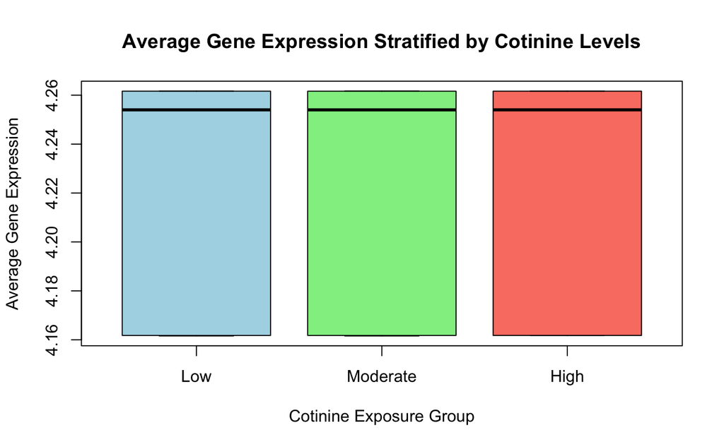

```r
#check for normalization of data
#"cc.mat" is a vector of maternal cotinine concentrations (independent variable)
cc.mat <- as.numeric(gsub(".*: ","",pheno$characteristics_ch1.10))
# And "edata" is a matrix where rows = genes, columns = samples (expression levels)

# Define cotinine exposure groups
quartiles <- quantile(cc.mat, probs = c(0.25, 0.50, 0.75)) # Compute quartiles
exposure_group <- cut(cc.mat,
                      breaks = c(-Inf, quartiles[1], quartiles[3], Inf),
                      labels = c("Low", "Moderate", "High"))

# Compute average gene expression per sample
avg_expression <- colMeans(edata)

# Create a dataframe
df <- data.frame(Sample = colnames(edata),
                 AvgExpression = avg_expression,
                 CotinineGroup = exposure_group)

# Box plot stratified by cotinine levels
boxplot(AvgExpression ~ CotinineGroup, data = df,
        main = "Average Gene Expression Stratified by Cotinine Levels",
        xlab = "Cotinine Exposure Group",
        ylab = "Average Gene Expression",
        col = c("lightblue", "lightgreen", "salmon"))
```

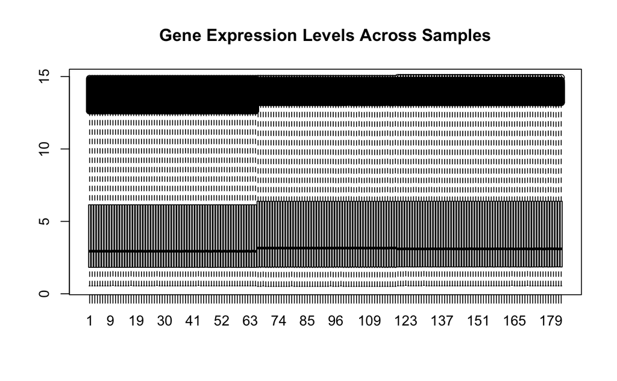

```r
#boxplot(edata, main = "Gene Expression Levels Across Samples")
boxplot(edata, main = "Gene Expression Levels Across Samples", xaxt="n")
axis(1, at=1:ncol(edata), labels=1:ncol(edata))
```

```r
NA
NA
```

To assess that normalization of the data was successful, I averaged the gene expression levels across all genes for each sample/patient. Each sample was then grouped by the independent variable as either low, medium or high cotinine levels (lowest 25%, IQR, highest 25%). The results of the average gene expressions per group can be seen on the box plot above. Here we see that the medians and overall distributions look the same between all groups. This is what we’d expect when our data has been normalized because quantile normalization (as used in the protocol for this data set) adjusts all samples so that the overall distribution of samples is equalized. This removes biases die to technical variability, as the overall median we are seeing for each group is a summary of 20k+ genes, we are investigating how the dependent variable affects individual gene expression, and don’t expect a difference in the overall average level of all genes in the sample. I also did a quick boxplot of the entire data set - due to the number of samples it is very crowded, but you can still see that the IQRs and Medians across all samples are fairly uniform.

> 1. 30 points With the downloaded data set, fit a linear model using the continuous annotation as the dependent variable and each gene expression as the dependent variable. Then calculate p-values for each linear model fit using an anova. This should generate a p-value for each gene. Next, calculate a corrected p-value using the Bonferoni correction and one using a FDR calculation. Annotate all three of these p-value calculations onto the data table that was downloaded. Next, generate scatter plots with genes ordered by the significance level for each independent p-value measurement, and the -log10(p-value) on the y-axis. Describe all these findings in addition to any changes in gene order by significance that are observed by the different p-value adjustments.

1. Limit data to placental samples.
2. Use apply() for lm + anova over each row.
3. extract p-value, calc bonferoni + FDR, add both to df
4. Scatter plots
5. Describe

```r
#limit data to placenta samples only
pheno.plac <- pheno[pheno$source_name_ch1=="term placenta, non-smoker" | pheno$source_name_ch1=="term placenta, smoker",]
edata.plac <- edata[,row.names(pheno.plac)]
#get cotinine maternal blood concentration from pheno.plac
cc.mat <- as.numeric(gsub(".*: ","",pheno.plac$characteristics_ch1.10))
```

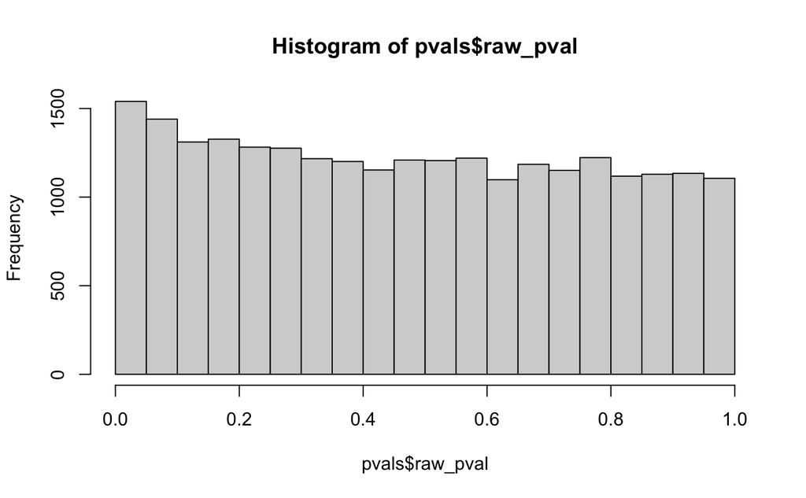

```r
# Create an empty data frame with gene names
pvals <- data.frame(Gene = rownames(edata.plac))

#fold change
fold_change <- rowMeans(edata.plac[, pheno.plac$source_name_ch1 == "term placenta, smoker"]) /
               rowMeans(edata.plac[, pheno.plac$source_name_ch1 == "term placenta, non-smoker"])

# Compute raw p-values using apply()
pvals$raw_pval <- apply(edata.plac, 1, function(gene_exprs){
  # Create a data frame where gene expression aligns with cotinine levels
  df.tmp <- data.frame(G= gene_exprs, CONC = cc.mat)

  # Fit linear model
  lm.tmp <- lm(CONC ~ G, df.tmp)

  # Extract p-value from ANOVA
  anova(lm.tmp)$"Pr(>F)"[1]
})
#view distribution of pvalues
hist(pvals$raw_pval)
```

```r
#

# Apply multiple testing corrections
pvals$bonferroni_pval <- p.adjust(pvals$raw_pval, method = "bonferroni") #if time - raw_pval / number samples
pvals$FDR_pval <- p.adjust(pvals$raw_pval, method = "fdr") #if time, try to replace with q-value script to find FDR

# create copy of edata + merge into copy
edata.results <- as.data.frame(edata.plac)
edata.results <- cbind(edata.plac, pvals[, -1])  # Drop Gene column, keep p-values
edata.results$Fold_Change <- fold_change

##fdr correction is not correlating with q-value
library(qvalue)
fdr_q <- qvalue(pvals$raw_pval)$qvalue
test <- matrix(data = c(fdr_q, edata.results$FDR_pval),ncol = 2, byrow = T)
```

Order by raw, bonferroni, FDR + plot each

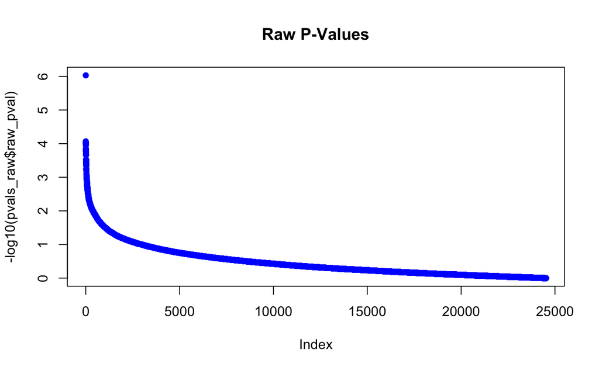

```r
# Order genes separately for each correction type
pvals_raw <- pvals[order(pvals$raw_pval), ]
pvals_bonferroni <- pvals[order(pvals$bonferroni_pval), ]
pvals_fdr <- pvals[order(pvals$FDR_pval), ]

# Scatter plots for each p-value type
#oldpar <- par(mfrow= c(1,3)) -- made plots too skinny
plot(-log10(pvals_raw$raw_pval), pch = 16, col = "blue", main = "Raw P-Values")
```

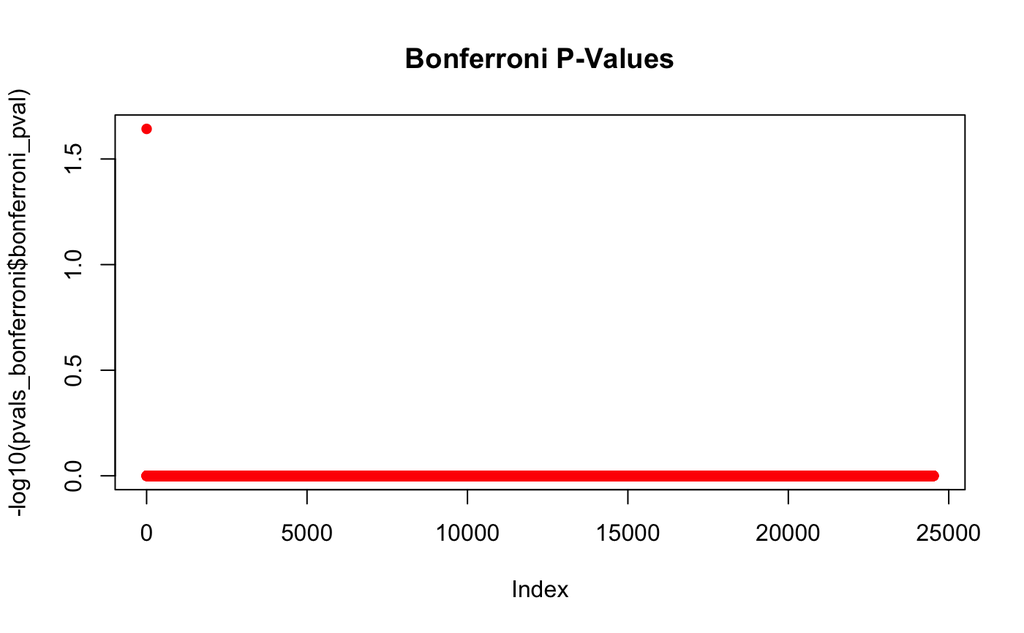

```r
plot(-log10(pvals_bonferroni$bonferroni_pval), pch = 16, col = "red", main = "Bonferroni P-Values")
```

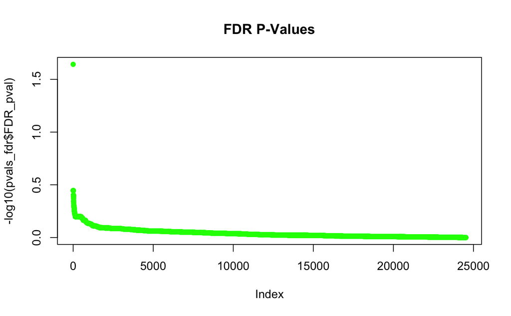

```r
plot(-log10(pvals_fdr$FDR_pval), pch = 16, col = "green", main = "FDR P-Values")
```

```r
#par(oldpar)
```

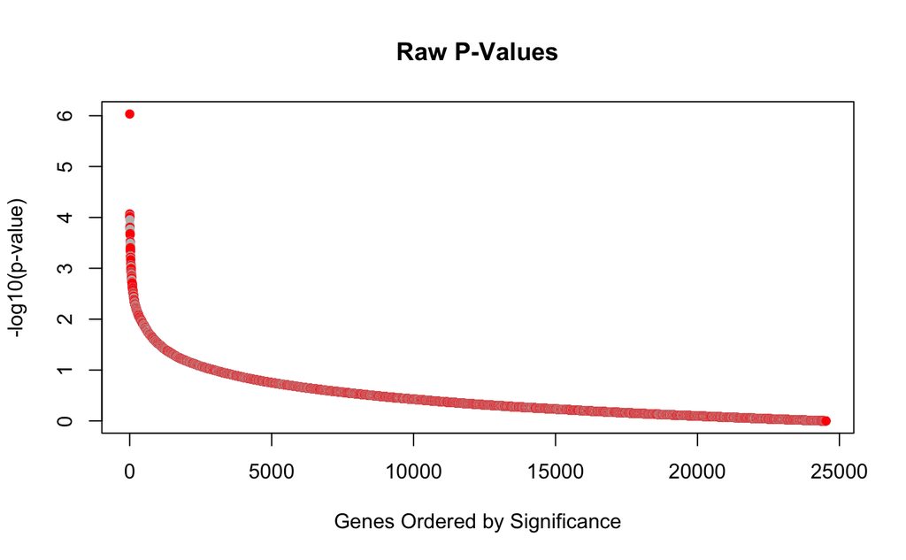

```r
# Order genes separately for each correction type
pvals_raw <- pvals[order(pvals$raw_pval), ]
pvals_bonferroni <- pvals[order(pvals$bonferroni_pval), ]
pvals_fdr <- pvals[order(pvals$FDR_pval), ]

# Merge fold change values
pvals_raw$Fold_Change <- edata.results$Fold_Change[match(pvals_raw$Gene, rownames(edata.results))]
pvals_bonferroni$Fold_Change <- edata.results$Fold_Change[match(pvals_bonferroni$Gene, rownames(edata.results))]
pvals_fdr$Fold_Change <- edata.results$Fold_Change[match(pvals_fdr$Gene, rownames(edata.results))]


fc_colors <- ifelse(pvals_raw$Fold_Change > 1, "red", ifelse(pvals_raw$Fold_Change < -1, "blue", "gray"))

#plots, incorporating fold change
plot(-log10(pvals_raw$raw_pval), col=fc_colors, pch=16,
     main="Raw P-Values", xlab="Genes Ordered by Significance", ylab="-log10(p-value)")
```

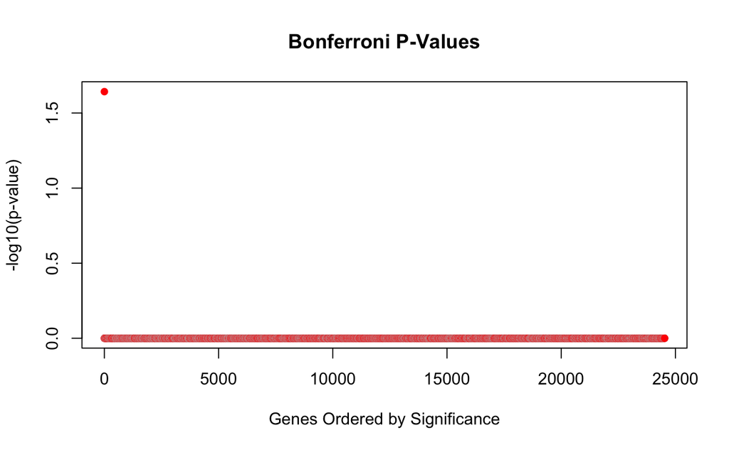

```r
plot(-log10(pvals_bonferroni$bonferroni_pval), col=fc_colors, pch=16,
     main="Bonferroni P-Values", xlab="Genes Ordered by Significance", ylab="-log10(p-value)")
```

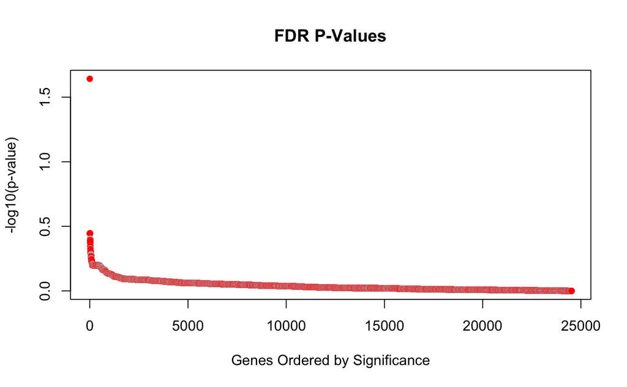

```r
plot(-log10(pvals_fdr$FDR_pval), col=fc_colors, pch=16,
     main="FDR P-Values", xlab="Genes Ordered by Significance", ylab="-log10(p-value)")
```

```r
NA
NA
NA
```

```r
#print top 5 genes for each sorting method
pvals_raw[1:5,]
```

|  | Gene | raw_pval | bonferroni_pval | FDR_pval | Fold_Change |
| --- | --- | --- | --- | --- | --- |
| 20852 | ILMN_2230683 | 9.286171e-07 | 0.02277526 | 0.02277526 | 1.0627182 |
| 5292 | ILMN_1696659 | 8.542721e-05 | 1.00000000 | 0.35863468 | 1.0523310 |
| 13496 | ILMN_1774901 | 9.326315e-05 | 1.00000000 | 0.35863468 | 0.9734127 |
| 9014 | ILMN_1731178 | 9.681504e-05 | 1.00000000 | 0.35863468 | 1.1295126 |
| 10071 | ILMN_1741131 | 1.001936e-04 | 1.00000000 | 0.35863468 | 1.0222556 |

```r
pvals_bonferroni[1:5,]
```

|  | Gene | raw_pval | bonferroni_pval | FDR_pval | Fold_Change |
| --- | --- | --- | --- | --- | --- |
| 20852 | ILMN_2230683 | 9.286171e-07 | 0.02277526 | 0.02277526 | 1.0627182 |
| 1 | ILMN_1343291 | 1.884270e-01 | 1.00000000 | 0.86949405 | 0.9967443 |
| 2 | ILMN_1651209 | 8.830135e-01 | 1.00000000 | 0.98785990 | 1.0121632 |
| 3 | ILMN_1651228 | 3.024552e-01 | 1.00000000 | 0.90058393 | 1.0119890 |
| 4 | ILMN_1651229 | 6.134497e-01 | 1.00000000 | 0.95914635 | 1.0063478 |

```r
pvals_fdr[1:5,]
```

|  | Gene | raw_pval | bonferroni_pval | FDR_pval | Fold_Change |
| --- | --- | --- | --- | --- | --- |
| 20852 | ILMN_2230683 | 9.286171e-07 | 0.02277526 | 0.02277526 | 1.062718 |
| 5292 | ILMN_1696659 | 8.542721e-05 | 1.00000000 | 0.35863468 | 1.052331 |
| 6003 | ILMN_1703178 | 1.564518e-04 | 1.00000000 | 0.35863468 | 1.286848 |
| 6595 | ILMN_1708588 | 2.193395e-04 | 1.00000000 | 0.35863468 | 1.204570 |
| 9014 | ILMN_1731178 | 9.681504e-05 | 1.00000000 | 0.35863468 | 1.129513 |

```r
# Compare number of significant genes detected
pvals.raw <- sum(pvals$raw_pval <0.05)
pvals.Bonferroni <- sum(pvals$bonferroni_pval < 0.05)
pvals.FDR <- sum(pvals$FDR_pval < 0.05)


cat("Number of significant genes (raw):", pvals.raw, "\n")
```

```
Number of significant genes (raw): 1540
```

```r
cat("Number of significant genes (Bonferroni):", pvals.Bonferroni, "\n")
```

```
Number of significant genes (Bonferroni): 1
```

```r
cat("Number of significant genes (FDR):", pvals.FDR, "\n")
```

```
Number of significant genes (FDR): 1
```

**DISCUSS**  
After using apply() to fit the linear model and ANOVA tests, I printed a histogram showing the distribution of raw p-values. I had a lot of trouble with this dataset—there are multiple tissues per patient and several concentrations to consider. I explored different combinations and initially missed incorporating fold change. While visualizing density histograms for different data combinations, I kept seeing uniform distributions. The only combination showing a slight skew toward p < 0.05 was maternal peripheral blood cotinine concentration paired with placental tissue for gene expression. Given how much time I spent familiarizing myself with this dataset, I suspected that the correlation between cotinine concentration (dependent variable) and gene expression (independent variable) might not be strong, but I proceeded to interpret the results.

The linear model tests the null hypothesis that there is no association between gene expression and cotinine concentration. ANOVA then determines whether gene expression significantly explains variance in cotinine concentration, meaning we are looking for low p-values to identify potential correlations.The -log10(p-value) plot of raw p-values highlights genes where expression is significantly associated with cotinine concentration. However, given the large number of genes analyzed, we expect some false positives due to multiple hypothesis testing. As the number of genes increases, the chance of false positives also increases (rather than sample size alone driving false discoveries). I did two sets of plots, my originals, and then another set that color codes the genes based on their fold change. I know the Bonferroni correction is very conservative, however I didn’t expect my significant genes to go from 1540 to 1. Likewise looking at the FDR correction, there are a few points on the left of the curve before it plateos out, but when ordering by most significant values there is also only one gene that that has a significant p-value (<0.05) from anova, however there are plenty around the 0.35 range, although this still accepts the null that there is no strong correlation between cotinine concentration and gene expression.

> 2. 30 points For each gene, compare average gene expression levels between samples separated by the same samples used in the fold change calculation performed when the dataset was downloaded using a Mann-Whitney U test of significance. Calculate FDR for this set of p-values and compare it with the results of Bonferroni corrected number of significant genes for the same set of p-values. Annotate the differences of expression you calculated along with the p-values that were obtained onto the data table. Next, compare these results to the p-value that is obtained from the downloaded data set. Describe your findings in plain English.

Steps:  
1. Compare avg gene exp levels b/w smokers/non-smokers w manW.  
2. FDR for pvals.  
3. Add exprs differences and pvals to df. 4. compare results to original pvals

```r
#find accessions for sample: maternal blood, outcome: smoker
smoker_acc <- row.names(pheno.plac[pheno.plac$source_name_ch1=="term placenta, smoker",]["geo_accession"])
#Find accessions for sample: cord blood, outcome: non-smoker
nonsm_acc <- row.names(pheno.plac[pheno.plac$source_name_ch1=="term placenta, non-smoker",]["geo_accession"])

# Partition data based on smoking status
smoker_data <- edata.plac[, smoker_acc]
nonsmoker_data <- edata.plac[, nonsm_acc]


# Create df for results
results <- data.frame(Gene = rownames(edata.plac),
                      Mean_Smoker = rowMeans(smoker_data),
                      Mean_NonSmoker = rowMeans(nonsmoker_data),
                      MWU_pval = NA)

# Mann-Whittney U test for each gene
for (i in 1:nrow(edata.plac)) {
  results$MWU_pval[i] <- wilcox.test(smoker_data[i, ], nonsmoker_data[i, ], exact = F)$p.value
}

#test corrections
results$MWU_FDR_pval <- p.adjust(results$MWU_pval, method = "fdr")
results$MWU_Bonf_pval <- p.adjust(results$MWU_pval, method = "bonferroni")

# Compare number of significant genes detected
significant_raw <- sum(results$MWU_pval <0.05)
significant_FDR <- sum(results$MWU_FDR_pval < 0.05)
significant_Bonferroni <- sum(results$MWU_Bonf_pval < 0.05)

cat("Number of significant genes (raw):", significant_raw, "\n")
```

```
Number of significant genes (raw): 1277
```

```r
cat("Number of significant genes (FDR):", significant_FDR, "\n")
```

```
Number of significant genes (FDR): 0
```

```r
cat("Number of significant genes (Bonferroni):", significant_Bonferroni, "\n")
```

```
Number of significant genes (Bonferroni): 0
```

**DISCUSS**  
After running both ANOVA (with fold change) and the Wilcoxon test (without fold change), some clear differences emerged in how each method detected significant genes. The ANOVA approach, which assumes a linear relationship between gene expression and cotinine concentration, initially identified 1540 genes as significant when using raw p-values. However, after applying multiple testing corrections (Bonferroni and FDR), only 1 gene remained significant, highlighting the large number of false positives that were filtered out. The Wilcoxon test, on the other hand, which compares gene expression medians between smoker and non-smoker samples, identified 1277 significant genes at the raw p-value level—but once corrections were applied, none remained significant.

This sugests that anova is sensitive to detecting subtle trends in gene expression, but because we are testing thousands of genes using hypothesis testing there are many that occur by chance, and we see that reduced to 1 significant gene appear once we apply the corrections. In the Mann-Whittney U test, which is non-parametric, we see that it doesn’t initally find as many genes as significant, when we apply the corrections it removed all of them suggesting that even though expression differences between groups exist, they are not strong enough to be statistically significant across samples.

> 3. Compare results of significance of gene expression and patient age relationship as assessed by ANOVA on linear model fit (same as we did before) and by permutation approach. Do not analyze all genes. Use the most and least significant gene ordered by adjusted p-value that was calculated from the differential expression analysis performed when the dataset was downloaded. For permutation based significance assessment obtain distributions both of: a) regression coefficient for slope of the fit (as returned by coef) and b) variance explained by it (as returned by anova in “Sum Sq” attribute). Derive re-sampling-based p-values for both these statistics by comparing their values from original fit with their distributions simulated under the null hypothesis of no association between gene expression level and age (this is the null we implement by permuting ages and/or gene expressions!). Describe results in writing and present them in the form of histograms of simulated distributions. In summary, you will take the expression levels of the selected genes. For each gene, take a sample of the gene expression level across all samples (regardless of treatment). Then fit a linear model to the continuous variable and extract the slope of the linear model and the p-value calculated using an anova. Then compare these results to a linear model using all of the data (original lm). Calculate the percentage of times the permuted slope is greater than or equal to the actual slope and the number of times the permuted p-values and less than or equal to the actual p-value.

Steps:  
1. Most and least significant genes. 2. permutations on genes

```r
most_significant <- pvals_raw$Gene[[1]]
least_significant <- pvals_raw$Gene[[nrow(pvals)-1]]

#create new df
org.vs.permu <- data.frame(gene = c(most_significant, least_significant), original_pval = numeric(2), original_slope= numeric(2))
#use cc.mat & most significant gene expression
lm.tmp <- lm(CONC ~ G, data = data.frame(G = edata.plac[most_significant,], CONC = cc.mat))
org.vs.permu$original_slope[1] <- lm.tmp$coefficients[2]
org.vs.permu$original_pval[1] <- anova(lm.tmp)$"Pr(>F)"[1]
org.vs.permu$original_sumSq[1] <- anova(lm.tmp)$"Sum Sq"[1]

#use cc.mat & least significant gene expression
lm.tmp <- lm(CONC ~ G, data = data.frame(G = edata.plac[least_significant,], CONC = cc.mat))
org.vs.permu$original_slope[2] <- lm.tmp$coefficients[2]
org.vs.permu$original_pval[2] <- anova(lm.tmp)$"Pr(>F)"[1]
org.vs.permu$original_sumSq[2] <- anova(lm.tmp)$"Sum Sq"[1]
```

```r
#permutate samples
#create df to store results
permute.df <- data.frame(matrix(ncol = 4, nrow = 10000))
colnames(permute.df) <- c("most_pval", "most_slope", "least_pval", "least_slope")

for (i in 1:10000){
  x.tmp <- sample(edata.plac[most_significant,])
  x.lm <- lm(x.tmp~cc.mat)
  permute.df$most_pval[i] <- anova(x.lm)$"Pr(>F)"[1]
  permute.df$most_slope[i] <- x.lm$coefficients[2]
  permute.df$most_SumS[i] <- anova(x.lm)$"Sum Sq"[1]
}

for (i in 1:10000){
  x.tmp <- sample(edata.plac[least_significant,])
  x.lm <- lm(x.tmp~cc.mat)
  permute.df$least_pval[i] <- anova(x.lm)$"Pr(>F)"[1]
  permute.df$least_slope[i] <- x.lm$coefficients[2]
  permute.df$least_SumS[i] <- anova(x.lm)$"Sum Sq"[1]
}

most_p_slope <- mean(permute.df$most_slope >= org.vs.permu$original_slope[1])
most_p_sum_sq <- mean(permute.df$most_SumS >= org.vs.permu$original_sumSq[1])
org.vs.permu$slope_percent[1] <- sum(permute.df$most_slope >= org.vs.permu$original_slope[1])/100
org.vs.permu$pval_count[1] <- sum(permute.df$most_pval <= org.vs.permu$original_pval[1])


org.vs.permu$slope_percent[2] <- sum(permute.df$least_slope >= org.vs.permu$original_slope[2])/100
org.vs.permu$pval_count[2] <- sum(permute.df$least_pval <= org.vs.permu$original_pval[2])
```

```r
par(mfrow=c(2,2)) # Arrange plots

# Histogram of permuted slopes for most significant gene
hist(permute.df$most_slope, col="blue", main="Most Sig Gene: Permuted Slopes", xlab="Slope")
abline(v=org.vs.permu$original_slope[1], col="red", lwd=2)  # Mark original slope

# Histogram of permuted p-values for most significant gene
hist(permute.df$most_pval, col="green", main="Most Sig Gene: Permuted P-values", xlab="P-value")
abline(v=org.vs.permu$original_pval[1], col="red", lwd=2)  # Mark original p-value

# Histogram of permuted slopes for least significant gene
hist(permute.df$least_slope, col="blue", main="Least Sig Gene: Permuted Slopes", xlab="Slope")
abline(v=org.vs.permu$original_slope[2], col="red", lwd=2)  # Mark original slope

# Histogram of permuted p-values for least significant gene
hist(permute.df$least_pval, col="green", main="Least Sig Gene: Permuted P-values", xlab="P-value")
abline(v=org.vs.permu$original_pval[2], col="red", lwd=2)  # Mark original p-value

par(mfrow=c(1,1)) # Reset plot layout
```

[output not shown]

```r
org.vs.permu
```

| gene | original_pval | original_slope | original_sumSq | slope_percent | pval_count |
| --- | --- | --- | --- | --- | --- |
| ILMN_2230683 | 9.286171e-07 | 3.031232e+01 | 1.271285e+04 | 0.00 | 12 |
| ILMN_1655137 | 9.999368e-01 | 8.913696e-04 | 4.149750e-06 | 27.91 | 9999 |